DS 3001: Foundations of Machine Learning

# Principal Component Analysis and Probability

[figure not shown]

# Principal Component Analysis

## Principal Component Analysis

- Several features may measure related properties and contain overlapping information.
- **Principal Component Analysis (PCA)** combines these features into new variables.
- We can then keep fewer variables while preserving most of the variation in the data.

This is **dimension reduction**.

Like clustering, PCA is unsupervised: there is no target outcome to predict.

## Overlapping Information

- Larger houses often have larger basements.
- These five illustrative houses show the overlap.

| House | House area (×100 sq ft) | Basement area (×100 sq ft) |
| --- | --- | --- |
| A | 17 | 5 |
| B | 19 | 9 |
| C | 20 | 8 |
| D | 21 | 7 |
| E | 23 | 11 |

## Overlapping Information

PCA can summarize much of this variation with one new variable.

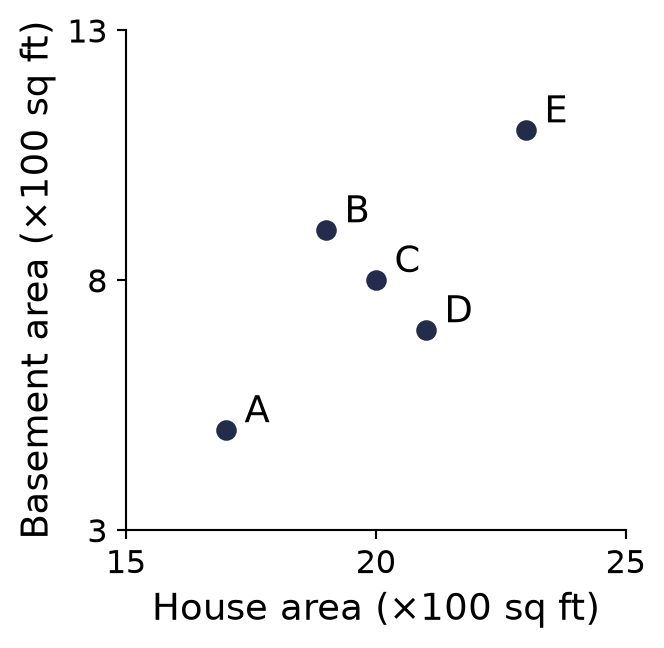

House and basement areas tend to increase together.

## Matrix–Vector Multiplication

Recall: multiplying a matrix by a vector takes the dot product of each row with the vector.

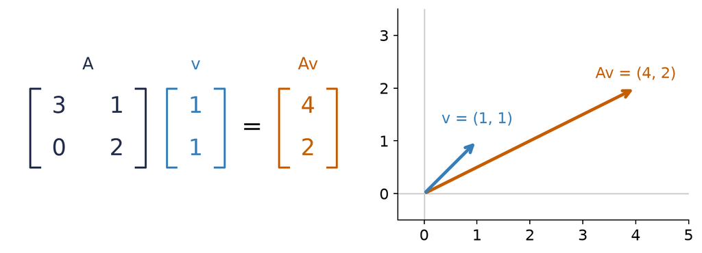

Multiplication changes (1, 1) into (4, 2): both direction and length change.  
Draw each vector as an arrow from $(0,0)$. The product $Av$ gives the new endpoint.

## Linear Algebra: Eigenvectors and Eigenvalues

- A nonzero vector $v$ is an **eigenvector** of $A$ when $Av=\lambda v$.
- The multiplier $\lambda$ is its **eigenvalue**.

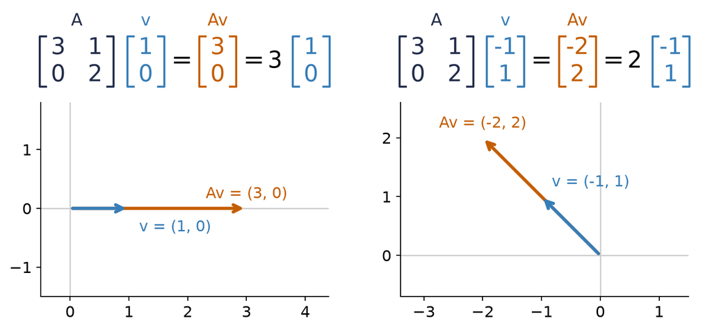

Blue: input. Orange: result. Each vector stays on its original line.  
Here, the eigenvalues give stretch factors of 3 for $(1,0)$ and 2 for $(-1,1)$.

## Linear Algebra: Transforming the Plane

- The same matrix transforms every point in the plane.
- Follow the grid and the three vectors as the transformation is applied.

[figure not shown]

The two eigenvectors stay on their original lines; $(1,1)$ changes direction.

## Linear Algebra: Matrix–Matrix Multiplication

Multiply $A$ by each column of $B$:

$$AB=A\begin{pmatrix}b_1&b_2\end{pmatrix}
=\begin{pmatrix}Ab_1&Ab_2\end{pmatrix}.$$

Using the same matrix and two vectors from the animation:

$$\underbrace{\begin{pmatrix}3&1\\0&2\end{pmatrix}}_{A}
\underbrace{\begin{pmatrix}1&-1\\1&1\end{pmatrix}}_{B}
=\begin{pmatrix}4&-2\\2&2\end{pmatrix}.$$

## Centering

Return to the five houses.

- The column means are 20 for house area and 8 for basement area.
- **Centering** subtracts each column’s mean:

$$z_1=\text{house area}-20,\qquad z_2=\text{basement area}-8.$$

$$X=\begin{pmatrix}17&5\\19&9\\20&8\\21&7\\23&11\end{pmatrix}
\quad\xrightarrow{\text{subtract column means}}\quad
Z=\begin{pmatrix}-3&-3\\-1&1\\0&0\\1&-1\\3&3\end{pmatrix}.$$

- Rows remain houses A–E; columns remain house area and basement area.
- Each centered column has mean zero.

## PCA and Covariance

PCA asks: **In which direction are these dots most spread out?**

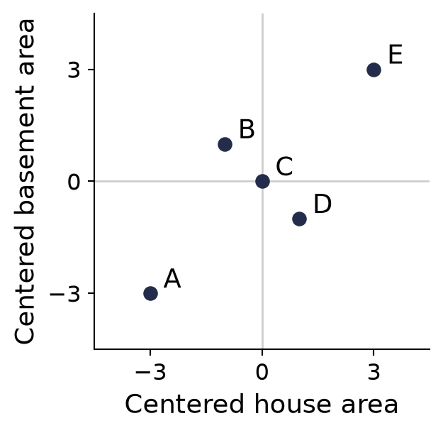

Each dot is a house.

## The Covariance Matrix

- Transposing $Z$ turns its centered columns into rows.
- The product $Z^{\mathsf T}Z$ computes the dot product of every pair of columns:

$$C=\frac{Z^{\mathsf T}Z}{n-1}
=\frac{1}{n-1}\begin{pmatrix}
z_1\cdot z_1&z_1\cdot z_2\\
z_2\cdot z_1&z_2\cdot z_2
\end{pmatrix}.$$

For the five houses, $n-1=4$:
$$C=\frac{1}{4}\begin{pmatrix}20&16\\16&20\end{pmatrix}
=\begin{pmatrix}5&4\\4&5\end{pmatrix}.$$

Variances are on the diagonal; covariances are off the diagonal.

## Covariance Eigenvectors

For this covariance matrix, the eigenvalues are 9 and 1:
$$\begin{pmatrix}5&4\\4&5\end{pmatrix}\begin{pmatrix}1\\1\end{pmatrix}
=\begin{pmatrix}9\\9\end{pmatrix}=9\begin{pmatrix}1\\1\end{pmatrix},$$
$$\begin{pmatrix}5&4\\4&5\end{pmatrix}\begin{pmatrix}-1\\1\end{pmatrix}
=\begin{pmatrix}-1\\1\end{pmatrix}=1\begin{pmatrix}-1\\1\end{pmatrix}.$$

The eigenvector with the largest eigenvalue points in the direction of greatest spread. Here, that direction is $(1,1)$.

## Linear Algebra: Unit Vectors

A **unit vector** has length one.

The vectors $(1,1)$ and $(-1,1)$ both have length $\sqrt{1^2+1^2}=\sqrt{2}$.

Dividing by this length gives
$$p_1=\frac{1}{\sqrt{2}}\begin{pmatrix}1\\1\end{pmatrix},\qquad
p_2=\frac{1}{\sqrt{2}}\begin{pmatrix}-1\\1\end{pmatrix}.$$

Their squared entries now add to 1.

## Linear Algebra: Orthogonality

Two nonzero vectors are **orthogonal** (perpendicular) when their dot product is zero:
$$p_1\cdot p_2=\frac{1(-1)+1(1)}{2}=0.$$

## Principal Components

The **principal components (PCs)** are the covariance matrix’s unit eigenvectors, ordered by decreasing eigenvalue.

A house’s **component scores** are its coordinates along PC1 ($p_1$) and PC2 ($p_2$):
$$\begin{aligned}
\text{PC1 score}&=(z_1,z_2)\cdot p_1=\frac{z_1+z_2}{\sqrt{2}},\\
\text{PC2 score}&=(z_1,z_2)\cdot p_2=\frac{-z_1+z_2}{\sqrt{2}}.
\end{aligned}$$

- PC1 scores increase with both areas and have the greatest variance.
- PC2 scores contrast basement area with house area.

## Transforming the Data

Each score is a weighted sum of a house’s centered areas:

| House | Centered house area | Centered basement area | PC1 score | PC2 score |
| --- | --- | --- | --- | --- |
| A | −3 | −3 | −4.24 | 0 |
| B | −1 | 1 | 0 | 1.41 |
| C | 0 | 0 | 0 | 0 |
| D | 1 | −1 | 0 | −1.41 |
| E | 3 | 3 | 4.24 | 0 |

- For house A, the PC1 score is $(-3-3)/\sqrt{2}\approx-4.24$.

## Dimension Reduction

- Each score column has one value per house.
- The two score columns have zero covariance.
- Keep PC1 and drop PC2.
- Each house is represented by one position along the first direction.

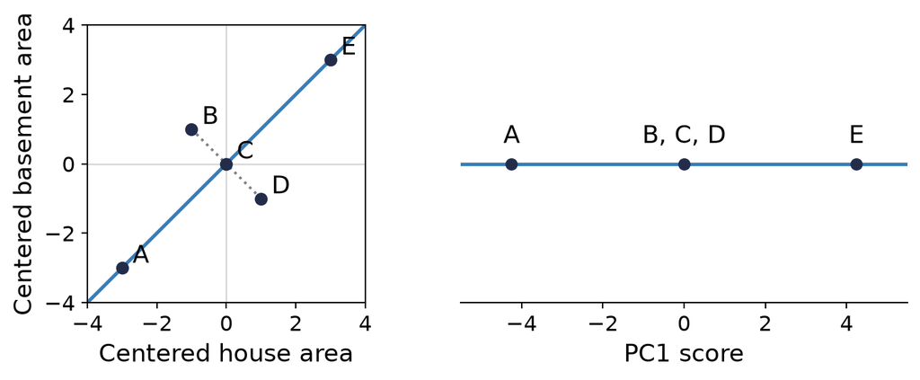

Units: hundreds of square feet. B, C, and D have the same PC1 score; their different combinations of areas are lost.

## Variance Retained

The centered areas and scores have mean zero. With five houses, sample variance is the sum of squared values divided by $5-1=4$.

| Column | Sample variance |
| --- | --- |
| Before: house area | $\frac{(-3)^2+(-1)^2+0^2+1^2+3^2}{4}=5$ |
| Before: basement area | $\frac{(-3)^2+1^2+0^2+(-1)^2+3^2}{4}=5$ |
| After: PC1 scores | $\frac{(-4.24)^2+0^2+0^2+0^2+4.24^2}{4}\approx9$ |
| After: PC2 scores | $\frac{0^2+1.41^2+0^2+(-1.41)^2+0^2}{4}\approx1$ |

Total variance stays the same: $5+5=9+1=10$.  
The score variances are the covariance eigenvalues, 9 and 1.

Keeping only PC1 retains $9/10=90\%$ of the total variance.

## Variance Retained

With more components, the same rule applies:

- Add the eigenvalues of the components we keep.
- Divide by the sum of all eigenvalues.

For the first $L$ of $K$ components, ordered by decreasing eigenvalue:
$$\text{Proportion retained}
=\frac{\lambda_1+\cdots+\lambda_L}{\lambda_1+\cdots+\lambda_K}.$$

## The PCA Algorithm

Let $X$ contain $N$ observations and $K$ features.  
We will keep $L\le K$ components.

1. **Center:** subtract each column’s mean to form $Z$.
2. **Calculate covariance:** form the $K\times K$ matrix $C=Z^{\mathsf T}Z/(N-1)$.
3. **Find directions:** calculate its unit eigenvectors and eigenvalues.  
   Order them by eigenvalue, largest first.

## The PCA Algorithm

4. **Transform:** put the first $L$ eigenvectors in a $K\times L$ matrix $P$ as columns, and calculate
   $$X_{\mathrm{PCA}}=ZP.$$
- Each row’s dot products with the columns of $P$ give its component scores.
- The result has $N$ rows and $L$ columns: the same observations, fewer features.

## Housing Features

The Pierce County data:  
16,814 house-sale records, with one record per row and eight features.

```python
df_house = pd.read_csv("./src/pierce_county_house_sales.csv")
features = [
    "house_square_feet", "attic_finished_square_feet",
    "basement_square_feet", "attached_garage_square_feet",
    "detached_garage_square_feet", "bedrooms", "bathrooms", "stories"
]
X_house = df_house[features].dropna()
```

## Housing Features

```python
preview_columns = ["house_square_feet", "basement_square_feet",
                   "bedrooms", "bathrooms"]
X_house[preview_columns].head()
```

|  | house_square_feet | basement_square_feet | bedrooms | bathrooms |
| --- | --- | --- | --- | --- |
| 0 | 2157 | 0 | 3 | 3 |
| 1 | 2238 | 0 | 4 | 3 |
| 2 | 1452 | 0 | 3 | 2 |
| 3 | 832 | 0 | 2 | 1 |
| 4 | 1780 | 384 | 3 | 2 |

- Four of the eight features: two areas in square feet and two room counts.
- Price is not included in this PCA.

## Housing Correlations

```python
correlations = X_house.corr()
```

|  | Correlation with house area |
| --- | --- |
| Bathrooms | 0.74 |
| Bedrooms | 0.59 |
| Attached garage area | 0.57 |

Larger houses tend to have more bathrooms and bedrooms, and larger attached garages.

## Housing PCA: Centering and Covariance

- Use all eight housing features in their original units.
- Center each column, then calculate the covariance matrix:

```python
Z_house = X_house - X_house.mean()
C_house = (Z_house.T @ Z_house) / (len(Z_house) - 1)
```

## Housing PCA: Find the Directions

Eigenvalues, largest first (PC1 to PC8):

```python
# eigh returns unit eigenvectors as columns.
eigenvalues, eigenvectors = np.linalg.eigh(C_house)
# Sort from largest eigenvalue to smallest.
order = np.argsort(eigenvalues)[::-1]
eigenvalues = eigenvalues[order]
eigenvectors = eigenvectors[:, order]
print(eigenvalues.round(2).tolist())
```

```
[607569.81, 187238.27, 52482.59, 24608.44, 10032.97, 0.55, 0.27, 0.14]
```

- Each eigenvector has eight entries, one for each original feature.
- The first column is PC1, the direction with the greatest score variance.

## Housing PCA: Transform the Data

Put the first three eigenvectors in $P$, then calculate each house’s scores:

```python
L = 3
P = eigenvectors[:, :L]
X_pca = Z_house @ P
explained_ratio = eigenvalues / eigenvalues.sum()
```

```python
print("Dimensions:", X_house.shape, "→", X_pca.shape)
print("Variance retained:", round(100 * explained_ratio[:L].sum(), 1), "%")
```

```
Dimensions: (16814, 8) → (16814, 3)
Variance retained: 96.1 %
```

Three score columns replace the eight features and retain **96.1%** of their total variance.

## PCA with Scikit-learn

- `fit` centers the features and finds the component directions.
- `transform` calculates the component scores:

```python
pca_house = PCA(n_components=3).fit(X_house)
X_pca_sklearn = pca_house.transform(X_house)
print("Rows and score columns:", X_pca_sklearn.shape)
print("Sklearn:", pca_house.explained_variance_ratio_.round(3))
print("Manual: ", explained_ratio[:3].round(3))
```

```
Rows and score columns: (16814, 3)
Sklearn: [0.689 0.212 0.06 ]
Manual:  [0.689 0.212 0.06 ]
```

- `explained_variance_ratio_` gives each component’s share of the total variance.
- The proportions agree with the manual calculation.

## Choosing the Number of Components

Suppose we want to retain at least 95% of the total variance.

```python
pca_full = PCA().fit(X_house)
# cumsum adds the successive components' variance proportions.
cumulative = np.cumsum(pca_full.explained_variance_ratio_)
```

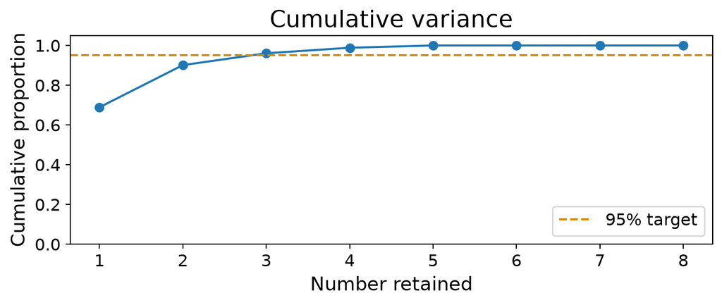

The cumulative total first exceeds the 95% target at three components (96.1%).

## Feature Scaling

Areas in square feet vary much more than room counts, so they have more influence on PCA.

**Min-max scaling:** values between 0 and 1.

```python
ranges = X_house.max() - X_house.min()
X_scaled = (X_house - X_house.min()) / ranges
pca_scaled = PCA().fit(X_scaled)
```

**Standardization:** mean 0 and variance 1.

```python
X_standardized = (X_house - X_house.mean()) / X_house.std()
pca_standardized = PCA().fit(X_standardized)
```

## Scaling Changes the Result

| Feature scale | 1 component (%) | 3 components (%) |
| --- | --- | --- |
| Original units | 68.9 | 96.1 |
| Min-max scaled | 50.5 | 80.7 |
| Standardized | 39.4 | 66.8 |

- Scaling changes the total variance and the directions PCA selects.
- Choose the scale before selecting the number of components.

## Using Component Scores

- Use the score columns as features for clustering or regression.

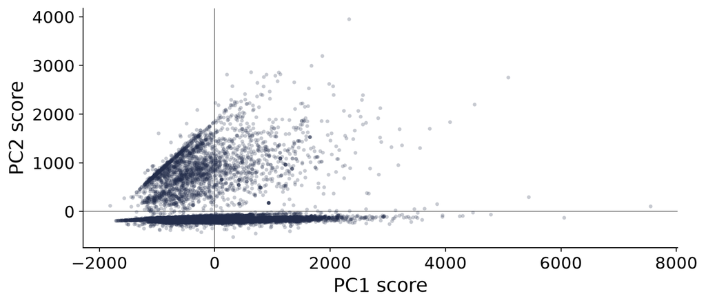

Each dot is one house. Using the original feature units, PC1 and PC2 retain 90.1% of total variance.

# Probability

## Probability

- We have tools to wrangle data, explore it, and build predictive models.
- Estimates can change if we collect another sample.
- Probability describes that randomness and helps us study how estimates behave across samples.

## A Fair Die

For one fair six-sided die:

- The **sample space** is $S=\{1,2,3,4,5,6\}$; each element is an **outcome**.
- An **event** is a set of outcomes, such as $A=\{2,4,6\}$ for an even roll.
- Each outcome has probability $1/6$.

Add the probabilities of the outcomes in the event:
$$P(A)=P(2)+P(4)+P(6)=\frac{3}{6}=\frac12.$$

## Probability Rules

For sample space $S$ and events $A$ and $B$:

1. Some outcome in $S$ must occur: $P(S)=1$.
   - An impossible event has probability zero.
2. Every event has a probability between zero and one: $0\le P(A)\le1$.
3. If $A$ and $B$ are **disjoint** (share no outcomes),
   $$P(A\text{ or }B)=P(A)+P(B).$$

For a die, “even” and “greater than 4” overlap at 6. Adding their probabilities would count that outcome twice.

## Two Dice

Roll two fair dice **independently**: knowing one result does not change the probabilities for the other.

Each ordered pair has probability $1/36$.

| Die 1 ↓ Die 2 → | 1 | 2 | 3 | 4 | 5 | 6 |
| --- | --- | --- | --- | --- | --- | --- |
| 1 | (1, 1) | (1, 2) | (1, 3) | (1, 4) | (1, 5) | (1, 6) |
| 2 | (2, 1) | (2, 2) | (2, 3) | (2, 4) | (2, 5) | (2, 6) |
| 3 | (3, 1) | (3, 2) | (3, 3) | (3, 4) | (3, 5) | (3, 6) |
| 4 | (4, 1) | (4, 2) | (4, 3) | (4, 4) | (4, 5) | (4, 6) |
| 5 | (5, 1) | (5, 2) | (5, 3) | (5, 4) | (5, 5) | (5, 6) |
| 6 | (6, 1) | (6, 2) | (6, 3) | (6, 4) | (6, 5) | (6, 6) |

## Two Dice

How many outcomes give a sum greater than 7?

| Sum | 8 | 9 | 10 | 11 | 12 |
| --- | --- | --- | --- | --- | --- |
| Number of outcomes | 5 | 4 | 3 | 2 | 1 |

Of the 36 outcomes, 15 have a sum greater than 7; the other 21 do not.

## Random Variables

A **random variable** assigns a number to each outcome.

Suppose you win $10 when the dice sum exceeds 7 and lose $5 otherwise. Your payoff is the random variable $R$:

| Outcome | Sum | Payoff $R$ |
| --- | --- | --- |
| $(3,6)$ | 9 | $10 |
| $(3,4)$ | 7 | −$5 |

The distribution of $R$ gives the probability of each payoff: $15/36$ for $10 and $21/36$ for −$5.

## Expectation

The **expected value** is the probability-weighted average of a random variable’s possible values:
$$\mathbb{E}[R]=\sum_r r\,P(R=r).$$

For the dice game:

$$\mathbb{E}[R]=10\left(\frac{15}{36}\right)-5\left(\frac{21}{36}\right)=1.25.$$

For random variables $R,T$ and constants $a,b$, **expectation is linear**:
$$\mathbb{E}[aR+bT]=a\mathbb{E}[R]+b\mathbb{E}[T].$$
Independence is not required.

## Revisiting Variance

For mean $\mu=\mathbb{E}[R]$, variance weights each squared deviation by its probability:
$$\mathbb{V}[R]=\mathbb{E}[(R-\mu)^2]
=\sum_r(r-\mu)^2P(R=r).$$

- Variance is written $\sigma^2$; standard deviation is $\sigma$.
- Standard deviation uses the same units as $R$.
- Scaling gives $\mathbb{V}[aR]=a^2\mathbb{V}[R]$.
- Adding a constant gives $\mathbb{V}[R+b]=\mathbb{V}[R]$.

## Variance of the Payoff

For the same game, $\mu=1.25$ and
$$\mathbb{V}[R]=\sum_r(r-1.25)^2P(R=r).$$

| Payoff $r$ | $P(R=r)$ | $(r-1.25)^2$ | Weighted square |
| --- | --- | --- | --- |
| 10 | $15/36$ | 76.5625 | 31.9010 |
| −5 | $21/36$ | 39.0625 | 22.7865 |

The weighted squares add to **54.6875**. The standard deviation is $\sqrt{54.6875}\approx7.40$ dollars.

A single payoff can be far from the expected value of $1.25.

## Independent and Identically Distributed Draws

Imagine repeating an experiment and observing $X_1,X_2,\ldots,X_n$.

The draws are **independent and identically distributed (iid)** when:

- every draw has the same distribution;
- knowing the other draws gives no information about a draw’s value.

We will assume a common mean $\mu$ and finite variance $\sigma^2$. The sample average is
$$\bar X_n=\frac1n\sum_{i=1}^nX_i.$$

## Averaging Independent Draws

The expected value of an average is the average of the expected values. This follows from **linearity of expectation**:
$$\mathbb{E}[\bar X_n]=\frac1n\sum_{i=1}^n\mathbb{E}[X_i]
=\frac{n\mu}{n}=\mu.$$

For independent draws, variances add. Using the variance scaling rule,
$$\mathbb{V}[\bar X_n]=\frac{1}{n^2}\sum_{i=1}^n\mathbb{V}[X_i]
=\frac{n\sigma^2}{n^2}=\frac{\sigma^2}{n}.$$

The standard deviation of the average is $\sigma/\sqrt n$.

## Law of Large Numbers

For iid draws with mean $\mu$ and finite variance, the **Weak Law of Large Numbers (WLLN)** says that the sample average converges in probability to $\mu$.

For any fixed error size $d>0$:
$$P\!\left(|\bar X_n-\mu|\ge d\right)\longrightarrow0
\quad\text{as }n\longrightarrow\infty.$$

As the sample grows, the chance that its average differs from $\mu$ by at least $d$ goes to zero.

## Estimating an Average

Return to the game that pays $10 for a sum greater than 7 and −$5 otherwise. Simulate 10,000 independent plays:

```python
rng = np.random.default_rng(3001)  # Reproducible random draws.
# integers excludes the upper endpoint, so each die is 1 through 6.
rolls = rng.integers(1, 7, size=(10000, 2))
sums = rolls.sum(axis=1)
payoffs = np.where(sums > 7, 10, -5)  # Choose the payoff for each play.
print("Mean payoff:", round(payoffs.mean(), 3))
```

```
Mean payoff: 1.222
```

The simulated average is $1.222, close to the expected payoff of $1.25. Individual plays still pay either $10 or −$5.

## Variation Across Samples

To assess uncertainty in our $1.222 estimate, generate 500 independent samples, each with $n=10{,}000$ plays.

```python
clt_rolls = rng_clt.integers(1, 7, size=(500, 10000, 2))
clt_payoffs = np.where(clt_rolls.sum(axis=2) > 7, 10, -5)
clt_averages = clt_payoffs.mean(axis=1)
```

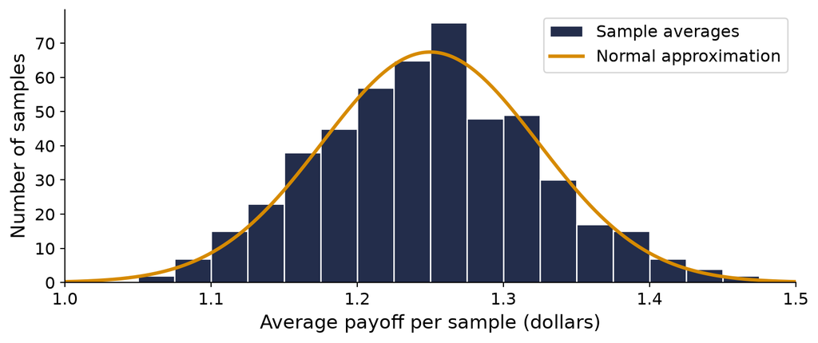

Sample averages cluster around $1.25, although individual plays pay only −$5 or $10.

## Central Limit Theorem (CLT)

- The LLN says sample averages approach the true mean $\mu$.
- How far from $\mu$ might a sample average still be?

**Theorem.** Let $\bar X_n$ be the average of $n$ iid draws with mean $\mu$ and finite variance $\sigma^2>0$. Then
$$\frac{\bar X_n-\mu}{\sigma/\sqrt n}
\xrightarrow{d}N(0,1)
\quad\text{as }n\to\infty.$$

- For large $n$, sample averages are approximately normal, centered at $\mu$ with standard deviation $\sigma/\sqrt n$.